# BASIC

```python
2+2
```

```python
print(4+6)
```

```python
print 5+5 #doesn't work, use parent.
```

```python
4  #int
4.3 # float
"hello world" # string
True #boolean
False #boolean
None # undefined
```

```python
type(4) # type() is useful for figuring out what kind of data you have
```

```python
type(5.4)
```

```python
type("hello world")
```

# Converting between types

```python
int(6.42)  #convert float -> int
```

```python
str(5)  # convert int -> string
```

```python
#group question
#How can we make this work?
print(5 + " is a number") # not work
```

```python
# group question
type(1/2)   # float, int, string?
```

# logic in python

```python
5 > 4
```

```python
# 5 >= 4, 5 <= 4, 5 == 4, 5 < 4, 5> 4
5 == 4 # false
5.0 == 5  # convert, True
5.0 == "5"  # false
```

```python
(5 > 4) and (5 < 3)
```

```python
#group question
(5 > 4) or (5 < 3)
```

# Variables

```python
x = 3.2
y = "hello world"
```

```python
helloHappyPeople = "hello world"
```

```python
helloHappyPeople  # tab to autocomplete
```

```python
z = "3.2"
#group question
x == z # False or True?
```

```python
#group question
x = True
y = False
z = False

if x or y and z:
    print('yes')
else:
    print('no')

# will the output be yes or no?
```

```python
#group question
x or (y and z)
```

```python
#group question
x or y or z
```

# tuples/lists/dictionaries

```python
names_tuples = ('alice','bob','sam')  # tuple, are not modifiable (immutable)
names_list  = ['alice','bob','sam']  #list, are changeable (mutable)
```

```python
names_tuples.append('jake')
```

```python
names_list.append('jake')
names_list
```

```python
names_list.insert(3,'chelsea')  # chelsea inserted at position 3
names_list
```

```python
names_list[1]  # to get bob
```

```python
names_list.pop()  # pull from end
```

```python
names_list
```

```python
names_list.index('sam')  #tell me where sam is in the list
```

```python
len(names_list)  # give me the length  --> 3 or 4
```

```python
a = [[1,2],[4,5]]
a[1][0]  # will I get 1,2,4, or 5?
```

```python
#group quesiton
a = [1,2,3,None,(),[],] # what is len(a)? 4,5,6,7 or error?
```

```python
# concat lists
list1 = [1,2,3,4]
list2 = [5,6,7,8]
list1 + list2
```

```python
#group question
#What is the answer?
"apple" + "bana"
```

# Objects in Python

```python
class Person:

    fullname = None   # this is a field
    weight = 0 # also a field
    height = 0 # also a field

    def __init__(self,name,w,h):  # constructor (make a new person)
        self.fullname = name
        self.weight = w
        self.height = h

    def getFullName(self):  # give me your name
        return(self.fullname)

    def setWeight(self,newweight):  # update your weight
        self.weight = newweight

    def getBMI(self):
        return(int(703*self.weight/(self.height*self.height)))
```

```python
alex = Person("alex",150,68)  # make a new instance of person
```

```python
jane = Person("jane",130,68)  # make a new instance
```

```python
alex.getFullName()   # what is your name?
```

```python
jane.getFullName()   # what is your name?
```

```python
alex.getBMI()  # what is your BMI?
```

```python
alex.setWeight(190)
```

```python
alex.getBMI()
```

# Pandas 101

```python
import numpy as np  #load up the libraries and object defs. we need
import pandas as pd
from pandas import DataFrame, Series
# tell ipython notebook to print visualizations into chrome
%pylab
%matplotlib inline
# load up my visualization system, and call the object plt
import matplotlib.pyplot as plt
```

```python
# defined a new class with students, years, and grades
myclass = pd.DataFrame({'student':['alice','bob','louis','jen'],\
                       'year':[4,4,3,3],\
                       'grade':[10,9,10,10]})
```

```python
myclass   # show me what the class looks like
```

```python
myclass.shape  # how many rows and columns
```

```python
myclass.columns  # give me the column names
```

```python
myclass.year.unique()  # give me the unique years
```

```python
pd.crosstab(myclass.grade,myclass.year)  # count me how many people are in each condition
```

```python
plt.hist(myclass.grade)
```

```python
pd.crosstab(myclass.year,myclass.grade)  #order reversed (x/y)
```

```python
myclass.info()
```

```python
myclass.describe()
```

```python
myclass.T  # get the transpose
```

```python
myclass = myclass.set_index('student')  # make a new dataframe based on myclass, BUT with student as the main/index key
myclass
```

```python
yrg = myclass.groupby('year')  # partition into groups I care about
yrg.describe()  # describe them  (statistical props. of each group)
```

```python
myclass.grade >= 10
```

```python
goodgrades = myclass.grade >= 10  # created a filter for students with good grades
goodgrades
```

```python
myclass[goodgrades]  # apply the filter
```

```python
myclass
```

```python
myclass.year == 4  # all people who are seniors
```

```python
(myclass.year == 4) & (myclass.grade >= 10)   # & = and for bit operations
```

```python
flt = (myclass.year == 4) & (myclass.grade >= 10)  # make the filtering criteria
myclass[flt]
```

```python
olive_oil = pd.read_csv('olive.csv')  # load up the file
```

# 1. Setup Environment and Import Data

```python
import matplotlib.pyplot as plt
import pandas as pd #this is how I usually import pandas
import sys #only needed to determine Python version number
import matplotlib #only needed to determine Matplotlib version number

# Enable inline plotting
%matplotlib inline
```

# 1.1 Install `statsmodels` package.

`statsmodels` is a Python package that provides various statistical analysis tools. We will use `statsmodels` for this lab. The package does not come with `Anaconda` by default, but we can easily install it.

- Open `Terminal` (or `cmd` in Windows)
- Choose an appropriate option:
  - If python3 is your default python, then type

    ```
    conda install statsmodels
    ```

  - If python3 is NOT your default python, which means you had to activate your Python environment before each session (e.g., "`source activate python3`" on Mac or "`activate python3`" on Windows), then do the following

    ```
    conda install --name=python3 statsmodels
    ```

    where `python3` should be whatever the name of your conda environment is.
- Follow the instructions to complete installation. Then come back to this notebook. The rest of the lab will be done within this notebook.

# 1.2 Import File

```python
#Even though this functions has many parameters, we will simply pass it the location of the text file.
#Location = C:\Users\fatem_000\OneDrive\Academic\2014 Summer\TA\599-VIS-Fall2016\Lab2\seeds-subset.csv
#Note: Depending on where you save your notebooks, you may need to modify the location above.

Location = r'C:\Users\fara\OneDrive\Academic\2014 Summer\TA\599-VIS-Fall2016\Lab2\olive.csv'
olive_oil = pd.read_csv(Location)  # load up the file

olive_oil
```

|  | Unnamed: 0 | region | area | palmitic | palmitoleic | stearic | oleic | linoleic | linolenic | arachidic | eicosenoic |
| --- | --- | --- | --- | --- | --- | --- | --- | --- | --- | --- | --- |
| 0 | 1.North-Apulia | 1 | 1 | 1075 | 75 | 226 | 7823 | 672 | 36 | 60 | 29 |
| 1 | 2.North-Apulia | 1 | 1 | 1088 | 73 | 224 | 7709 | 781 | 31 | 61 | 29 |
| 2 | 3.North-Apulia | 1 | 1 | 911 | 54 | 246 | 8113 | 549 | 31 | 63 | 29 |
| 3 | 4.North-Apulia | 1 | 1 | 966 | 57 | 240 | 7952 | 619 | 50 | 78 | 35 |
| 4 | 5.North-Apulia | 1 | 1 | 1051 | 67 | 259 | 7771 | 672 | 50 | 80 | 46 |
| 5 | 6.North-Apulia | 1 | 1 | 911 | 49 | 268 | 7924 | 678 | 51 | 70 | 44 |
| 6 | 7.North-Apulia | 1 | 1 | 922 | 66 | 264 | 7990 | 618 | 49 | 56 | 29 |
| 7 | 8.North-Apulia | 1 | 1 | 1100 | 61 | 235 | 7728 | 734 | 39 | 64 | 35 |
| 8 | 9.North-Apulia | 1 | 1 | 1082 | 60 | 239 | 7745 | 709 | 46 | 83 | 33 |
| 9 | 10.North-Apulia | 1 | 1 | 1037 | 55 | 213 | 7944 | 633 | 26 | 52 | 30 |
| 10 | 11.North-Apulia | 1 | 1 | 1051 | 35 | 219 | 7978 | 605 | 21 | 65 | 24 |
| 11 | 12.North-Apulia | 1 | 1 | 1036 | 59 | 235 | 7868 | 661 | 30 | 62 | 44 |
| 12 | 13.North-Apulia | 1 | 1 | 1074 | 70 | 214 | 7728 | 747 | 50 | 79 | 33 |
| 13 | 14.North-Apulia | 1 | 1 | 875 | 52 | 243 | 8018 | 655 | 41 | 79 | 32 |
| 14 | 15.North-Apulia | 1 | 1 | 952 | 49 | 254 | 7795 | 780 | 50 | 75 | 41 |
| 15 | 16.North-Apulia | 1 | 1 | 1155 | 98 | 201 | 7606 | 816 | 32 | 60 | 29 |
| 16 | 17.North-Apulia | 1 | 1 | 943 | 94 | 183 | 7840 | 788 | 42 | 75 | 31 |
| 17 | 18.North-Apulia | 1 | 1 | 1278 | 69 | 205 | 7344 | 957 | 45 | 70 | 28 |
| 18 | 19.North-Apulia | 1 | 1 | 961 | 70 | 195 | 7958 | 742 | 46 | 75 | 30 |
| 19 | 20.North-Apulia | 1 | 1 | 952 | 77 | 258 | 7820 | 736 | 43 | 78 | 33 |
| 20 | 21.North-Apulia | 1 | 1 | 1074 | 67 | 236 | 7692 | 716 | 56 | 83 | 45 |
| 21 | 22.North-Apulia | 1 | 1 | 995 | 46 | 288 | 7806 | 679 | 56 | 86 | 40 |
| 22 | 23.North-Apulia | 1 | 1 | 1056 | 53 | 247 | 7703 | 700 | 54 | 89 | 51 |
| 23 | 24.North-Apulia | 1 | 1 | 1065 | 39 | 234 | 7876 | 703 | 42 | 74 | 26 |
| 24 | 25.North-Apulia | 1 | 1 | 1065 | 45 | 245 | 7779 | 696 | 47 | 82 | 38 |
| 25 | 26.Calabria | 1 | 2 | 1315 | 139 | 230 | 7299 | 832 | 42 | 60 | 32 |
| 26 | 27.Calabria | 1 | 2 | 1321 | 136 | 217 | 7174 | 950 | 43 | 63 | 30 |
| 27 | 28.Calabria | 1 | 2 | 1359 | 115 | 246 | 7234 | 874 | 45 | 63 | 18 |
| 28 | 29.Calabria | 1 | 2 | 1378 | 111 | 272 | 7127 | 940 | 46 | 64 | 23 |
| 29 | 30.Calabria | 1 | 2 | 1295 | 109 | 245 | 7253 | 903 | 43 | 62 | 38 |
| ... | ... | ... | ... | ... | ... | ... | ... | ... | ... | ... | ... |
| 542 | 543.West-Liguria | 3 | 8 | 1020 | 100 | 290 | 7620 | 960 | 0 | 10 | 2 |
| 543 | 544.West-Liguria | 3 | 8 | 970 | 90 | 220 | 7700 | 1020 | 0 | 0 | 3 |
| 544 | 545.West-Liguria | 3 | 8 | 1180 | 130 | 220 | 7450 | 1010 | 0 | 10 | 2 |
| 545 | 546.West-Liguria | 3 | 8 | 1060 | 140 | 240 | 7690 | 850 | 10 | 10 | 1 |
| 546 | 547.West-Liguria | 3 | 8 | 990 | 100 | 250 | 7630 | 1030 | 0 | 0 | 3 |
| 547 | 548.West-Liguria | 3 | 8 | 1010 | 90 | 350 | 7630 | 940 | 10 | 0 | 3 |
| 548 | 549.West-Liguria | 3 | 8 | 1040 | 90 | 250 | 7780 | 820 | 10 | 10 | 1 |
| 549 | 550.West-Liguria | 3 | 8 | 1040 | 90 | 250 | 7810 | 810 | 10 | 10 | 2 |
| 550 | 551.West-Liguria | 3 | 8 | 1020 | 90 | 350 | 7620 | 920 | 10 | 0 | 3 |
| 551 | 552.West-Liguria | 3 | 8 | 1020 | 90 | 260 | 7620 | 1010 | 0 | 0 | 3 |
| 552 | 553.West-Liguria | 3 | 8 | 1010 | 90 | 350 | 7610 | 930 | 10 | 0 | 3 |
| 553 | 554.West-Liguria | 3 | 8 | 920 | 110 | 340 | 7720 | 910 | 0 | 0 | 3 |
| 554 | 555.West-Liguria | 3 | 8 | 1030 | 100 | 250 | 7710 | 900 | 0 | 10 | 2 |
| 555 | 556.West-Liguria | 3 | 8 | 960 | 90 | 300 | 7820 | 830 | 0 | 0 | 3 |
| 556 | 557.West-Liguria | 3 | 8 | 1030 | 110 | 210 | 7810 | 840 | 0 | 0 | 1 |
| 557 | 558.West-Liguria | 3 | 8 | 1010 | 100 | 240 | 7710 | 910 | 10 | 20 | 2 |
| 558 | 559.West-Liguria | 3 | 8 | 1020 | 90 | 240 | 7800 | 850 | 0 | 0 | 2 |
| 559 | 560.West-Liguria | 3 | 8 | 1120 | 90 | 300 | 7650 | 830 | 0 | 10 | 1 |
| 560 | 561.West-Liguria | 3 | 8 | 1090 | 90 | 290 | 7710 | 800 | 10 | 0 | 2 |
| 561 | 562.West-Liguria | 3 | 8 | 1100 | 120 | 280 | 7630 | 770 | 10 | 10 | 2 |
| 562 | 563.West-Liguria | 3 | 8 | 1090 | 80 | 240 | 7820 | 760 | 10 | 0 | 2 |
| 563 | 564.West-Liguria | 3 | 8 | 1150 | 90 | 250 | 7720 | 810 | 0 | 10 | 3 |
| 564 | 565.West-Liguria | 3 | 8 | 1110 | 90 | 230 | 7810 | 750 | 0 | 10 | 2 |
| 565 | 566.West-Liguria | 3 | 8 | 1010 | 110 | 210 | 7720 | 950 | 0 | 0 | 1 |
| 566 | 567.West-Liguria | 3 | 8 | 1070 | 100 | 220 | 7730 | 870 | 10 | 10 | 2 |
| 567 | 568.West-Liguria | 3 | 8 | 1280 | 110 | 290 | 7490 | 790 | 10 | 10 | 2 |
| 568 | 569.West-Liguria | 3 | 8 | 1060 | 100 | 270 | 7740 | 810 | 10 | 10 | 3 |
| 569 | 570.West-Liguria | 3 | 8 | 1010 | 90 | 210 | 7720 | 970 | 0 | 0 | 2 |
| 570 | 571.West-Liguria | 3 | 8 | 990 | 120 | 250 | 7750 | 870 | 10 | 10 | 2 |
| 571 | 572.West-Liguria | 3 | 8 | 960 | 80 | 240 | 7950 | 740 | 10 | 20 | 2 |

572 rows × 11 columns

# 1.3 Import Data

Let us start with necessary imports and data loading. Just execute every cell below. Remember: a convenient shortcut to run a cell and then jumps to the next cell is `Shirt + Enter`.

```python
# This is the Anscombe's quartet
# Source - Wikipedia: https://en.wikipedia.org/wiki/Anscombe%27s_quartet
from io import StringIO

TESTDATA=StringIO("""X1,Y1,X2,Y2,X3,Y3,X4,Y4
10,8.04,10,9.14,10,7.46,8,6.58
8,6.95,8,8.14,8,6.77,8,5.76
13,7.58,13,8.74,13,12.74,8,7.71
9,8.81,9,8.77,9,7.11,8,8.84
11,8.33,11,9.26,11,7.81,8,8.47
14,9.96,14,8.1,14,8.84,8,7.04
6,7.24,6,6.13,6,6.08,8,5.25
4,4.26,4,3.1,4,5.39,19,12.5
12,10.84,12,9.13,12,8.15,8,5.56
7,4.82,7,7.26,7,6.42,8,7.91
5,5.68,5,4.74,5,5.73,8,6.89""")

df = pd.DataFrame.from_csv(TESTDATA, index_col=None)
df
```

|  | X1 | Y1 | X2 | Y2 | X3 | Y3 | X4 | Y4 |
| --- | --- | --- | --- | --- | --- | --- | --- | --- |
| 0 | 10 | 8.04 | 10 | 9.14 | 10 | 7.46 | 8 | 6.58 |
| 1 | 8 | 6.95 | 8 | 8.14 | 8 | 6.77 | 8 | 5.76 |
| 2 | 13 | 7.58 | 13 | 8.74 | 13 | 12.74 | 8 | 7.71 |
| 3 | 9 | 8.81 | 9 | 8.77 | 9 | 7.11 | 8 | 8.84 |
| 4 | 11 | 8.33 | 11 | 9.26 | 11 | 7.81 | 8 | 8.47 |
| 5 | 14 | 9.96 | 14 | 8.10 | 14 | 8.84 | 8 | 7.04 |
| 6 | 6 | 7.24 | 6 | 6.13 | 6 | 6.08 | 8 | 5.25 |
| 7 | 4 | 4.26 | 4 | 3.10 | 4 | 5.39 | 19 | 12.50 |
| 8 | 12 | 10.84 | 12 | 9.13 | 12 | 8.15 | 8 | 5.56 |
| 9 | 7 | 4.82 | 7 | 7.26 | 7 | 6.42 | 8 | 7.91 |
| 10 | 5 | 5.68 | 5 | 4.74 | 5 | 5.73 | 8 | 6.89 |

This dataset contains 4 groups of data: `(X1, Y1)`, to `(X4, Y4)`.

It is not hard to notice that `X1`, `X2`, and `X3` are identical. But that doesn't matter now.

We can do a quick vis of the data by creating scatterplots.

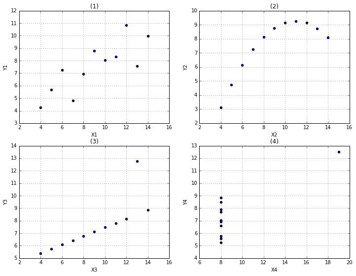

```python
fig, axs = plt.subplots(2, 2, figsize=(12,9))
for i, ax in enumerate(axs.flat):
    j = i + 1
    ax.scatter(df['X%d'%j], df['Y%d'%j])
    ax.set_title('(%d)'%j)
    ax.set_xlabel('X%d'%j)
    ax.set_ylabel('Y%d'%j)
    ax.grid(True)
```

# 2. Compute Summary Statistics

Pandas `DataFrames` and `Series` come with a couple of convenient functions for computing basic summary statistics. Try the following commands. Their meanings are quite self-explanatory.

```python
df.mean()
```

```
X1    9.000000
Y1    7.500909
X2    9.000000
Y2    7.500909
X3    9.000000
Y3    7.500000
X4    9.000000
Y4    7.500909
dtype: float64
```

```python
df.median()
```

```
X1    9.00
Y1    7.58
X2    9.00
Y2    8.14
X3    9.00
Y3    7.11
X4    8.00
Y4    7.04
dtype: float64
```

```python
df.std()
```

```
X1    3.316625
Y1    2.031568
X2    3.316625
Y2    2.031657
X3    3.316625
Y3    2.030424
X4    3.316625
Y4    2.030579
dtype: float64
```

```python
df.max()
```

```
X1    14.00
Y1    10.84
X2    14.00
Y2     9.26
X3    14.00
Y3    12.74
X4    19.00
Y4    12.50
dtype: float64
```

```python
# This one computes the maximum along the 1st axies (i.e,. across columns).
df.max(axis=1)
```

```
0     10.00
1      8.14
2     13.00
3      9.00
4     11.00
5     14.00
6      8.00
7     19.00
8     12.00
9      8.00
10     8.00
dtype: float64
```

```python
df.var()
```

```
X1    11.000000
Y1     4.127269
X2    11.000000
Y2     4.127629
X3    11.000000
Y3     4.122620
X4    11.000000
Y4     4.123249
dtype: float64
```

You can also apply the functions on a column (i.e,. a Series), too. Such as...

```python
df.X1.mean()
```

```
9.0
```

```python
# This one is slightly more complicated... But you can figure this out easily.
(df.X1 + df.X2).mean()
```

```
18.0
```

```python
# And finally...
df.describe()
```

|  | X1 | Y1 | X2 | Y2 | X3 | Y3 | X4 | Y4 |
| --- | --- | --- | --- | --- | --- | --- | --- | --- |
| count | 11.000000 | 11.000000 | 11.000000 | 11.000000 | 11.000000 | 11.000000 | 11.000000 | 11.000000 |
| mean | 9.000000 | 7.500909 | 9.000000 | 7.500909 | 9.000000 | 7.500000 | 9.000000 | 7.500909 |
| std | 3.316625 | 2.031568 | 3.316625 | 2.031657 | 3.316625 | 2.030424 | 3.316625 | 2.030579 |
| min | 4.000000 | 4.260000 | 4.000000 | 3.100000 | 4.000000 | 5.390000 | 8.000000 | 5.250000 |
| 25% | 6.500000 | 6.315000 | 6.500000 | 6.695000 | 6.500000 | 6.250000 | 8.000000 | 6.170000 |
| 50% | 9.000000 | 7.580000 | 9.000000 | 8.140000 | 9.000000 | 7.110000 | 8.000000 | 7.040000 |
| 75% | 11.500000 | 8.570000 | 11.500000 | 8.950000 | 11.500000 | 7.980000 | 8.000000 | 8.190000 |
| max | 14.000000 | 10.840000 | 14.000000 | 9.260000 | 14.000000 | 12.740000 | 19.000000 | 12.500000 |

# 3. Binning, Grouping, and Histograms

To quickly understand the distribution of data, it is a good idea to use binning and grouping and creating histograms.

## 3.1 Binning and Grouping

Use the following code to create bins based on `X1`'s values, and check the mean value of both `X1` and `Y1` within each bin.

```python
# Since we have very few data points, I will only use 3 bins (by setting num = 4)
bins_by_x1 = np.linspace(start=3, stop=15, num=4)
groups_by_x1 = df[['X1','Y1']].groupby(pd.cut(df.X1, bins_by_x1))
groups_by_x1.mean()
```

| X1 | X1 | Y1 |
| --- | --- | --- |
| (3, 7] | 5.5 | 5.5000 |
| (7, 11] | 9.5 | 8.0325 |
| (11, 15] | 13.0 | 9.4600 |

The above result shows the **mean** value of `X1` and `Y1` binned by the value of `X1`.

To understand what is going on in the above commands, feel free to print out the intermediate variables, including:

- `bins_by_x1`
- `pd.cut(df.X1, bins_by_x1)`
- `groups_by_x1`

Also try the following commands:

```python
groups_by_x1.median()
```

| X1 | X1 | Y1 |
| --- | --- | --- |
| (3, 7] | 5.5 | 5.250 |
| (7, 11] | 9.5 | 8.185 |
| (11, 15] | 13.0 | 9.960 |

```python
groups_by_x1.size().to_frame(name='count')
```

| X1 | count |
| --- | --- |
| (3, 7] | 4 |
| (7, 11] | 4 |
| (11, 15] | 3 |

In addition to using existing aggregate functions (i.e., `max, min, mean, median, size`, etc.), you can also define custom functions to "`apply`" to the grouping object.

The following should generate the same result as the previous one. Try to figure out how it works.

```python
groups_by_x1.apply(lambda x: len(x)).to_frame(name='count')
```

| X1 | count |
| --- | --- |
| (3, 7] | 4 |
| (7, 11] | 4 |
| (11, 15] | 3 |

```python
# Or, alternatively, and more confusingly ...
groups_by_x1.apply(lambda x: pd.Series({'count': len(x)}))
```

| X1 | count |
| --- | --- |
| (3, 7] | 4 |
| (7, 11] | 4 |
| (11, 15] | 3 |

## 3.2 Creating Histograms

To create a histogram, simply use `.hist()` on a `Series` object. It automatically handles binning, grouping, and counting.

By default, `hist()` generates 10 bins. You may customize this by specifying the `bins` parameter, for example, `hist(bins=5)`.

Try the following.

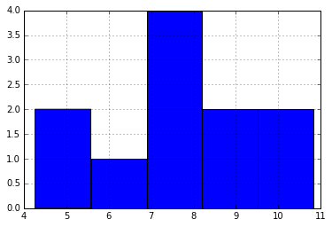

```python
df.Y1.hist(bins=5)
```

you may call `hist()` on a `DataFrame` object and obtain a panel of histograms, one for each individual column.

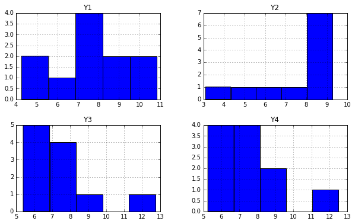

```python
_ = df[['Y1','Y2','Y3','Y4']].hist(bins=5, figsize=(10,6))
```

In the above example, notice two things:

- I used `figsize=(10, 6)` to specify the size of the figure (the unit is inch, although the `%matplotlib inline` configuration reduces the figure sizes by a predefined ratio automatically).
- I put "`_ =`" in the front to avoid seeing the returned value of `df.hist`, which I do not care. If you are curious, it is an array of `axes` objects of `matplotlib`.
  - In general, `_` can be used whenever you want to ignore the return value of a function.

You can also make histograms that have side-by-side bars for multiple variables. For the following example, I used `matplotlib`'s `hist` function instead of the equivalence of `pandas`, because it is easier to use the former one to make side-by-side histograms like this.

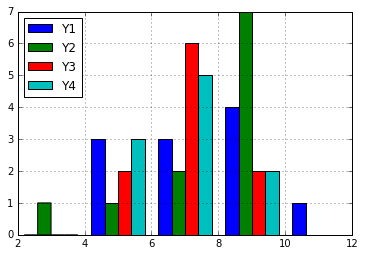

```python
bins = np.linspace(start=2, stop=12, num=6)
plt.hist(df[['Y1','Y2','Y3','Y4']].values,
         bins,
         label=['Y1','Y2','Y3','Y4'])
plt.legend(loc="upper left")
plt.grid(True)
```

## 3.3 Boxplots

Using `pandas`, it is very easy to create a boxplot of multiple variables.

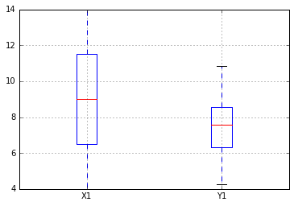

```python
_ = df[['X1','Y1']].boxplot()
```